# Detecting fake news: binary classification of fake vs. true news based on textual characteristics of news articles

Author

Sarah Gauthier, Jessie Liang and Vinay Valson

Published

November 19, 2025

**Note**: The model fitting code runs up to 5 minutes.

```python
import numpy as np
import pandas as pd
from sklearn.dummy import DummyClassifier
from sklearn.feature_extraction.text import CountVectorizer
from sklearn.model_selection import(
    GridSearchCV,
    RandomizedSearchCV,
    cross_validate,
    train_test_split,
)
from sklearn.naive_bayes import BernoulliNB, MultinomialNB
from sklearn.dummy import DummyClassifier
from sklearn.pipeline import Pipeline, make_pipeline
import matplotlib.pyplot as plt
from wordcloud import WordCloud
from sklearn.compose import ColumnTransformer
from sklearn.feature_extraction.text import CountVectorizer
from sklearn.preprocessing import OneHotEncoder, FunctionTransformer
from scipy.stats import expon, lognorm, loguniform, randint, uniform, norm, randint
from sklearn.metrics import ConfusionMatrixDisplay, PrecisionRecallDisplay, RocCurveDisplay, classification_report
import pandera.pandas as pa
```

## Introduction

“Fake news”, also known as disinformation, is deliberately misleading or false information presented as legitimate news (Service Canada, 2024). Its rapid spread in recent years has becoming a pressing concern, particularly with the rise of social media platforms that accelerate the dissemination of content. These platforms are designed with the primary objective of capturing and retaining user attention for as long as possible. To that end, fake news often exploits this design to gain traction.

There is high public awareness of this issue in Canada. In 2023, Statistics Canada reported that 59% of Canadians admitted that they were “very or extremely concerned about online misinformation” in the Survey Series on People and their Communities (Bilodeau and Khalid, 2024). In the United States, the concept of “fake news” grew in popularity during the 2016 presidential election. Allcott and Gentzkow (2017) estimated that false news stories were shared on Facebook at least 38 million times in the 3 months leading up to the election. Such widespread circulation of this false information can have serious consequences, including influencing public opinion and undermining trust in legitimate news sources. Thus, methods for detecting fake news may be beneficial in mitigating its spread.

This report investigates whether a machine learning model can accurately classify news articles as “fake” or “true” based on their textual characteristics, such as the article’s title, subject and body content. Automated detection of fake news has the potential to mitigate the spread and impact of information, particularly in social media’s fast-paced environment where information is shared instantly and at scale, from numerous sources.

## Data

The dataset used in this analysis is the “Fake and Real News Dataset” available on Kaggle, [here](https://www.kaggle.com/datasets/clmentbisaillon/fake-and-real-news-dataset). It contains approximately 40,000 news articles published in the United States between 2015 and 2018. Each row in the dataset represents a news article, with a column for its title, subject, date, and body text.

The raw data from Kaggle was initially provided as two seperate datasets: one for the fake articles and one for the true articles. To prepare the data for modeling, we conducted some validation checks to make sure the data was in the expected format, with no missing observations or duplicate entries. The two datasets were then merged into one large one, with an additional column for the `target` value, indicating whether the article was labeled as “true” or “fake”. To support model training and evaluation, we shuffled the rows and split the data into training (80%) and testing (20%) sets. Further validation was conducted on the training set to identify outliers and anomoulous correlations. Finally, we conducted exploratory data analysis (EDA) on the training data set to examine the distribution of the target variable and gain initial insights into the dataset.

```python
true_url = "../data/raw/True.csv"
fake_url = "../data/raw/Fake.csv"

# Check if file format is .csv
if not (true_url.lower().endswith(".csv") and fake_url.lower().endswith(".csv")):
    raise ValueError("Data file must be in .csv format.")

# Read in data from .csv files
true_df = pd.read_csv(true_url)
fake_df = pd.read_csv(fake_url)
```

```python
true_df['target'] = 'True'
true_df['subject'] = true_df['subject'].replace('politicsNews', 'political')
true_df['subject'] = true_df['subject'].replace('worldnews', 'non-political')
true_df.head()
```

|  | title | text | subject | date | target |
| --- | --- | --- | --- | --- | --- |
| 0 | As U.S. budget fight looms, Republicans flip t... | WASHINGTON (Reuters) - The head of a conservat... | political | December 31, 2017 | True |
| 1 | U.S. military to accept transgender recruits o... | WASHINGTON (Reuters) - Transgender people will... | political | December 29, 2017 | True |
| 2 | Senior U.S. Republican senator: 'Let Mr. Muell... | WASHINGTON (Reuters) - The special counsel inv... | political | December 31, 2017 | True |
| 3 | FBI Russia probe helped by Australian diplomat... | WASHINGTON (Reuters) - Trump campaign adviser ... | political | December 30, 2017 | True |
| 4 | Trump wants Postal Service to charge 'much mor... | SEATTLE/WASHINGTON (Reuters) - President Donal... | political | December 29, 2017 | True |

```python
fake_df['target'] = 'Fake'
fake_df['subject'] = fake_df['subject'].replace('politics', 'political')
fake_df['subject'] = fake_df['subject'].replace('left-news', 'political')
fake_df['subject'] = fake_df['subject'].replace('Government News', 'political')
fake_df['subject'] = fake_df['subject'].replace('News', 'non-political')
fake_df['subject'] = fake_df['subject'].replace('US_News', 'non-political')
fake_df['subject'] = fake_df['subject'].replace('Middle-east', 'non-political')
fake_df.head()
```

|  | title | text | subject | date | target |
| --- | --- | --- | --- | --- | --- |
| 0 | Donald Trump Sends Out Embarrassing New Year’... | Donald Trump just couldn t wish all Americans ... | non-political | December 31, 2017 | Fake |
| 1 | Drunk Bragging Trump Staffer Started Russian ... | House Intelligence Committee Chairman Devin Nu... | non-political | December 31, 2017 | Fake |
| 2 | Sheriff David Clarke Becomes An Internet Joke... | On Friday, it was revealed that former Milwauk... | non-political | December 30, 2017 | Fake |
| 3 | Trump Is So Obsessed He Even Has Obama’s Name... | On Christmas day, Donald Trump announced that ... | non-political | December 29, 2017 | Fake |
| 4 | Pope Francis Just Called Out Donald Trump Dur... | Pope Francis used his annual Christmas Day mes... | non-political | December 25, 2017 | Fake |

### Data Validation

**Part 1**: Perform the following data validation checks: - Correct column names - No empty observations - Missingness not beyond expected threshold - Correct data types in each column - No duplicate observations

```python
true_df = true_df.drop_duplicates()

schema = pa.DataFrameSchema(
    {
        "title": pa.Column(str),
        "text": pa.Column(str),
        "subject": pa.Column(str,
                             pa.Check(lambda s: s.isna().mean() <= 0.05,
                                      element_wise=False,
                                      error = "Too many null values in 'subject' column")),
        "date": pa.Column(str, nullable=True),
    },
    checks = [
        pa.Check(lambda df: ~df.duplicated().any(), error = "Duplicate rows found."),
        pa.Check(lambda df: ~(df.isna().all(axis=1)).any(), error = "Empty rows found.")
    ],
    drop_invalid_rows=True
)

schema.validate(true_df, lazy=True)
```

|  | title | text | subject | date | target |
| --- | --- | --- | --- | --- | --- |
| 0 | As U.S. budget fight looms, Republicans flip t... | WASHINGTON (Reuters) - The head of a conservat... | political | December 31, 2017 | True |
| 1 | U.S. military to accept transgender recruits o... | WASHINGTON (Reuters) - Transgender people will... | political | December 29, 2017 | True |
| 2 | Senior U.S. Republican senator: 'Let Mr. Muell... | WASHINGTON (Reuters) - The special counsel inv... | political | December 31, 2017 | True |
| 3 | FBI Russia probe helped by Australian diplomat... | WASHINGTON (Reuters) - Trump campaign adviser ... | political | December 30, 2017 | True |
| 4 | Trump wants Postal Service to charge 'much mor... | SEATTLE/WASHINGTON (Reuters) - President Donal... | political | December 29, 2017 | True |
| ... | ... | ... | ... | ... | ... |
| 21412 | 'Fully committed' NATO backs new U.S. approach... | BRUSSELS (Reuters) - NATO allies on Tuesday we... | non-political | August 22, 2017 | True |
| 21413 | LexisNexis withdrew two products from Chinese ... | LONDON (Reuters) - LexisNexis, a provider of l... | non-political | August 22, 2017 | True |
| 21414 | Minsk cultural hub becomes haven from authorities | MINSK (Reuters) - In the shadow of disused Sov... | non-political | August 22, 2017 | True |
| 21415 | Vatican upbeat on possibility of Pope Francis ... | MOSCOW (Reuters) - Vatican Secretary of State ... | non-political | August 22, 2017 | True |
| 21416 | Indonesia to buy $1.14 billion worth of Russia... | JAKARTA (Reuters) - Indonesia will buy 11 Sukh... | non-political | August 22, 2017 | True |

21211 rows × 5 columns

```python
fake_df = fake_df.drop_duplicates()
schema.validate(fake_df, lazy=True)
```

|  | title | text | subject | date | target |
| --- | --- | --- | --- | --- | --- |
| 0 | Donald Trump Sends Out Embarrassing New Year’... | Donald Trump just couldn t wish all Americans ... | non-political | December 31, 2017 | Fake |
| 1 | Drunk Bragging Trump Staffer Started Russian ... | House Intelligence Committee Chairman Devin Nu... | non-political | December 31, 2017 | Fake |
| 2 | Sheriff David Clarke Becomes An Internet Joke... | On Friday, it was revealed that former Milwauk... | non-political | December 30, 2017 | Fake |
| 3 | Trump Is So Obsessed He Even Has Obama’s Name... | On Christmas day, Donald Trump announced that ... | non-political | December 29, 2017 | Fake |
| 4 | Pope Francis Just Called Out Donald Trump Dur... | Pope Francis used his annual Christmas Day mes... | non-political | December 25, 2017 | Fake |
| ... | ... | ... | ... | ... | ... |
| 22698 | The White House and The Theatrics of ‘Gun Cont... | 21st Century Wire says All the world s a stage... | non-political | January 7, 2016 | Fake |
| 22699 | Activists or Terrorists? How Media Controls an... | Randy Johnson 21st Century WireThe majority ... | non-political | January 7, 2016 | Fake |
| 22700 | BOILER ROOM – No Surrender, No Retreat, Heads ... | Tune in to the Alternate Current Radio Network... | non-political | January 6, 2016 | Fake |
| 22701 | Federal Showdown Looms in Oregon After BLM Abu... | 21st Century Wire says A new front has just op... | non-political | January 4, 2016 | Fake |
| 22702 | A Troubled King: Chicago’s Rahm Emanuel Desper... | 21st Century Wire says It s not that far away.... | non-political | January 2, 2016 | Fake |

17910 rows × 5 columns

**Part 2**: Perform the following data validation checks on `true_df` and `fake_df`: - No outlier or anomalous values - Correct category levels (i.e., no string mismatches or single values)

```python
complete_df = pd.concat([true_df, fake_df])

# Split into train/test data sets
train_df, test_df = train_test_split(
    complete_df, train_size=0.80, random_state=123
)
```

```python
schema2 = pa.DataFrameSchema(
    {
        "title": pa.Column(
            str,
            pa.Check((lambda x: x.str.len().between(5, 1000)),
                     error="Outlier title length detected")
        ),
        "text": pa.Column(
            str,
            pa.Check((lambda x: x.str.len().between(20, 80000)),
                     error="Outlier text length detected")
        ),
        "subject": pa.Column(
            str,
            pa.Check((lambda x: x.isin(['political', 'non-political'])),
                     error="Incorrect subject category levels")
        ),
        "date": pa.Column(
            str,
            pa.Check((lambda x: pd.to_datetime(x,
                                              format='mixed',
                                              errors='coerce').between(pd.Timestamp('1980-01-01'),
                                                        pd.Timestamp.now())),
                     error="Outlier news date detected")
        ),
        "target": pa.Column(
            str,
            pa.Check((lambda x: x.isin(['True', 'Fake'])),
                     error="Incorrect target category levels")
        )
    }
)
```

```python
train_df = train_df[train_df['text'].str.len() >= 20]
train_df = train_df[pd.to_datetime(train_df['date'],
                                   format='mixed',
                                   errors='coerce').notna()]

schema2.validate(train_df, lazy=True)
```

|  | title | text | subject | date | target |
| --- | --- | --- | --- | --- | --- |
| 1442 | Trump’s Leaks To Russia May Well Have Put Ind... | Trump s ignorance, incompetence, and ego are p... | non-political | May 16, 2017 | Fake |
| 10725 | Republican Senator Kirk says he wants Senate t... | WASHINGTON (Reuters) - Republican Senator Mark... | political | February 22, 2016 | True |
| 2780 | Massive copper mine tests Trump's push to slas... | SUPERIOR, Arizona (Reuters) - Rio Tinto’s prop... | political | July 13, 2017 | True |
| 6773 | Patton Oswalt To Bernie Fans: ‘You’re A F*cki... | Comedian Patton Oswalt has a knack for calling... | non-political | April 21, 2016 | Fake |
| 13638 | U.S. general sees no change in Pakistan behavi... | WASHINGTON (Reuters) - The top U.S. general in... | non-political | November 28, 2017 | True |
| ... | ... | ... | ... | ... | ... |
| 7807 | Clinton heavily favored to win Electoral Colle... | NEW YORK (Reuters) - After a brutal week for ... | political | October 15, 2016 | True |
| 15556 | Polish reforms of judiciary pose threat to rul... | BRUSSELS (Reuters) - Polish reforms of its jud... | non-political | November 6, 2017 | True |
| 17920 | Factbox: Japan main parties' key election pled... | TOKYO (Reuters) - Campaigning began on Tuesday... | non-political | October 10, 2017 | True |
| 6819 | Jared Fogle’s Pedophilic Texts Finally Releas... | Former Subway spokesman and outed pedophile Ja... | non-political | April 19, 2016 | Fake |
| 15905 | Iran's Rouhani: Tehran-Moscow cooperation need... | ANKARA (Reuters) - Iran s President Hassan Rou... | non-political | November 1, 2017 | True |

30903 rows × 5 columns

```python
# check target/response variable follows expected distribution:
def expected_target_distribution(df):
    return (df['target'].value_counts(normalize=True) < 0.8).all()

# check no anomalous correlations between target/response variable
# and features/explanatory variables
def normal_corr_target_features(df):
    target = df['target'].map({
        "True": 1,
        "Fake": 0
    })
    title_length = df['title'].str.len()
    text_length = df['text'].str.len()
    numeric_subject = df['subject'].map({
        "political": 1,
        "non-political": 0
    })
    # Since date will be dropped later, no need to check its correlation

    for casted_feaure in [title_length, text_length, numeric_subject]:
        correlation = target.corr(casted_feaure)
        if correlation > 0.8:
            return False

    return True

# check no anomalous correlations between features/explanatory variables
def normal_corr_between_features(df):
    title_length = df['title'].str.len()
    text_length = df['text'].str.len()
    numeric_subject = df['subject'].map({
        "political": 1,
        "non-political": 0
    })
    # Since date will be dropped later, no need to check its correlation

    corr1 = title_length.corr(text_length)
    corr2 = title_length.corr(numeric_subject)
    corr3 = text_length.corr(numeric_subject)
    for corr in [corr1, corr2, corr3]:
        if corr > 0.8:
            return False

    return True
```

```python
schema3 = pa.DataFrameSchema(
    checks=[pa.Check(expected_target_distribution,
                     error="Target does not follow expected distribution"),
            pa.Check(normal_corr_target_features,
                     error="Anomalous correlations between target and features")]
)
```

```python
schema3.validate(train_df)
```

|  | title | text | subject | date | target |
| --- | --- | --- | --- | --- | --- |
| 1442 | Trump’s Leaks To Russia May Well Have Put Ind... | Trump s ignorance, incompetence, and ego are p... | non-political | May 16, 2017 | Fake |
| 10725 | Republican Senator Kirk says he wants Senate t... | WASHINGTON (Reuters) - Republican Senator Mark... | political | February 22, 2016 | True |
| 2780 | Massive copper mine tests Trump's push to slas... | SUPERIOR, Arizona (Reuters) - Rio Tinto’s prop... | political | July 13, 2017 | True |
| 6773 | Patton Oswalt To Bernie Fans: ‘You’re A F*cki... | Comedian Patton Oswalt has a knack for calling... | non-political | April 21, 2016 | Fake |
| 13638 | U.S. general sees no change in Pakistan behavi... | WASHINGTON (Reuters) - The top U.S. general in... | non-political | November 28, 2017 | True |
| ... | ... | ... | ... | ... | ... |
| 7807 | Clinton heavily favored to win Electoral Colle... | NEW YORK (Reuters) - After a brutal week for ... | political | October 15, 2016 | True |
| 15556 | Polish reforms of judiciary pose threat to rul... | BRUSSELS (Reuters) - Polish reforms of its jud... | non-political | November 6, 2017 | True |
| 17920 | Factbox: Japan main parties' key election pled... | TOKYO (Reuters) - Campaigning began on Tuesday... | non-political | October 10, 2017 | True |
| 6819 | Jared Fogle’s Pedophilic Texts Finally Releas... | Former Subway spokesman and outed pedophile Ja... | non-political | April 19, 2016 | Fake |
| 15905 | Iran's Rouhani: Tehran-Moscow cooperation need... | ANKARA (Reuters) - Iran s President Hassan Rou... | non-political | November 1, 2017 | True |

30903 rows × 5 columns

### Data Preprocessing

```python
X_train, y_train = train_df.drop(columns=["target"]), train_df["target"]
X_test, y_test = test_df.drop(columns=["target"]), test_df["target"]
```

## Methods

### EDA

```python
train_df.info()
```

```
<class 'pandas.core.frame.DataFrame'>
Index: 30903 entries, 1442 to 15905
Data columns (total 5 columns):
 #   Column   Non-Null Count  Dtype
---  ------   --------------  -----
 0   title    30903 non-null  object
 1   text     30903 non-null  object
 2   subject  30903 non-null  object
 3   date     30903 non-null  object
 4   target   30903 non-null  object
dtypes: object(5)
memory usage: 1.4+ MB
```

### Count of Fake vs. Real News Articles

Figure 1: Count of true vs. fake news articles in training data set

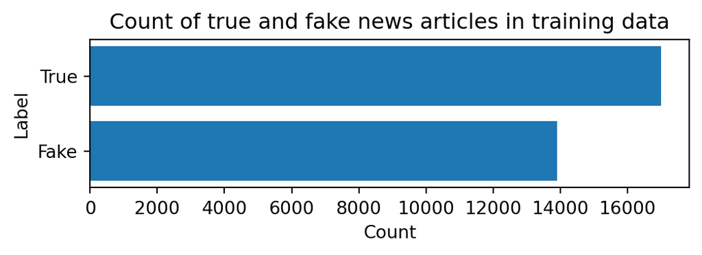

```python
counts = train_df['target'].value_counts().sort_index()

plt.figure(figsize=(6, 1.5))
plt.barh(counts.index, counts.values)

# Labels and title
plt.xlabel('Count')
plt.ylabel('Label')
plt.title('Count of true and fake news articles in training data')

plt.show()
```

```python
train_df['target'].value_counts()
```

```
target
True    16998
Fake    13905
Name: count, dtype: int64
```

```python
fake_text = train_df[train_df['target'] == 'Fake']['text']
true_text = train_df[train_df['target'] == 'True']['text']

# Remove "'s" instances (possessives/contractions)
fake_text = fake_text.str.replace(r"\bs\b", "", regex=True)
true_text = true_text.str.replace(r"\bs\b", "", regex=True)

# remove punctuation
fake_text = fake_text.str.replace(r'[^\w\s]', '', regex=True)
true_text = true_text.str.replace(r'[^\w\s]', '', regex=True)

fake_words = fake_text.str.cat(sep=" ")
true_words = true_text.str.cat(sep=" ")

fake_titles = train_df[train_df['target'] == 'Fake']['title']
true_titles = train_df[train_df['target'] == 'True']['title']

# remove punctuation
fake_titles = fake_titles.str.replace(r'[^\w\s]', '', regex=True)
true_ttitles = true_titles.str.replace(r'[^\w\s]', '', regex=True)

# Remove "'s" instances (possessives/contractions)
fake_titles = fake_titles.str.replace(r"\bs\b", "", regex=True)
true_titles = true_titles.str.replace(r"\bs\b", "", regex=True)

fake_title_words = fake_titles.str.cat(sep=" ")
true_title_words = true_titles.str.cat(sep=" ")
```

### Word Clouds for Titles Column

Figure 2: Word cloud for titles of fake news articles

[figure not shown]

```python
# Generate word cloud for fake news titles
fake_wordcloud = WordCloud(width=800, height=400, background_color='white').generate(fake_title_words)

plt.figure(figsize=(10, 5))
plt.imshow(fake_wordcloud, interpolation='bilinear')
plt.axis('off')
plt.title('Word Cloud for Fake News Titles')
plt.show()
```

Figure 3: Word cloud for titles of true news articles

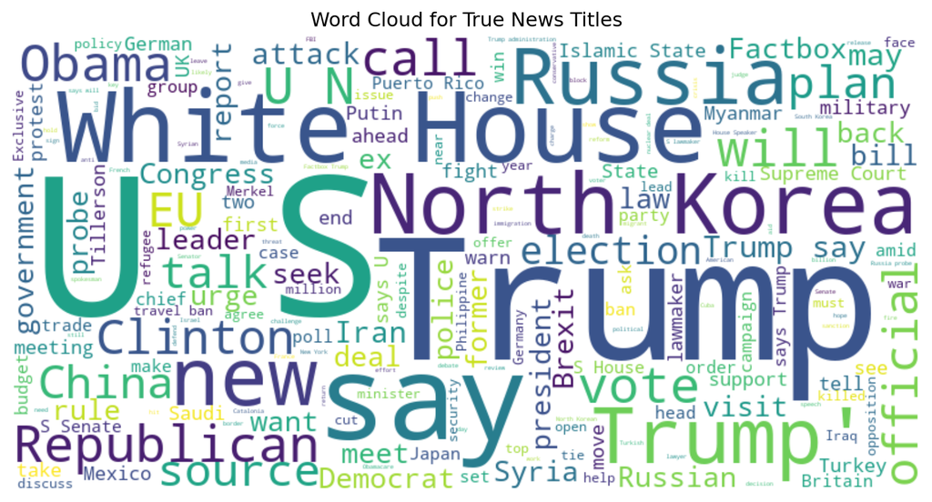

```python
# Generate word cloud for true news titles
true_wordcloud = WordCloud(width=800, height=400, background_color='white').generate(true_title_words)

plt.figure(figsize=(10, 5))
plt.imshow(true_wordcloud, interpolation='bilinear')
plt.axis('off')
plt.title('Word Cloud for True News Titles')
plt.show()
```

### Model Building

```python
# Create preprocessing pipeline
preprocessor = ColumnTransformer(
    transformers=[
        ('title_text', CountVectorizer(max_features=5000, stop_words='english'), 'title'),
        ('text_text', CountVectorizer(max_features=10000, stop_words='english'), 'text'),
        ('subject', OneHotEncoder(drop='first'), ['subject'])
    ],
    remainder='drop'
)

# Create pipeline with Naive Bayes
nb_pipeline = Pipeline([
    ('preprocessor', preprocessor),
    ('classifier', MultinomialNB())
])

# Fit the model
nb_pipeline.fit(X_train, y_train)
```

```
Pipeline(steps=[('preprocessor',
                 ColumnTransformer(transformers=[('title_text',
                                                  CountVectorizer(max_features=5000,
                                                                  stop_words='english'),
                                                  'title'),
                                                 ('text_text',
                                                  CountVectorizer(max_features=10000,
                                                                  stop_words='english'),
                                                  'text'),
                                                 ('subject',
                                                  OneHotEncoder(drop='first'),
                                                  ['subject'])])),
                ('classifier', MultinomialNB())])
```

### Model Evaluation

```python
# Make predictions
y_pred = nb_pipeline.predict(X_test)
y_pred_proba = nb_pipeline.predict_proba(X_test)

# Print classification report
print("Classification Report:")
print(classification_report(y_test, y_pred))
```

```
Classification Report:
              precision    recall  f1-score   support

        Fake       0.94      0.95      0.95      3613
        True       0.96      0.95      0.95      4212

    accuracy                           0.95      7825
   macro avg       0.95      0.95      0.95      7825
weighted avg       0.95      0.95      0.95      7825
```

```python
# Calculate accuracy
accuracy = nb_pipeline.score(X_test, y_test)
print(f"Test Accuracy: {accuracy:.3f}")
```

```
Test Accuracy: 0.951
```

### Baseline Model Comparison

```python
# Create dummy classifier for baseline
dummy_clf = DummyClassifier(strategy='most_frequent')
dummy_clf.fit(X_train, y_train)
dummy_pred = dummy_clf.predict(X_test)
dummy_accuracy = dummy_clf.score(X_test, y_test)

print(f"Baseline (Dummy) Accuracy: {dummy_accuracy:.3f}")
print(f"Naive Bayes Accuracy: {accuracy:.3f}")
print(f"Improvement: {accuracy - dummy_accuracy:.3f}")
```

```
Baseline (Dummy) Accuracy: 0.538
Naive Bayes Accuracy: 0.951
Improvement: 0.413
```

## Conclusion

The machine learning approach using Naive Bayes classification shows promising results for fake news detection. The model’s high accuracy and balanced performance across both classes suggest it could be a valuable tool in combating misinformation. However, the model’s performance may be limited to the types of news articles present in the training data, and further validation on diverse news sources would be beneficial for real-world deployment.